# Machine Learning Course Project

Damion Rosbrugh

May 13, 2017

## Background

Through the use of data collected by accelerometers on various wearable electronic devices such as the Fitbit and other such products, it possible to observe a wide range of human motions and decompose those motions into componants which can be used to classify particular activities.

We will use data from accelerometers worn on the belt, forearm, arm, and dumbell of 6 people as they performed barbell lifts in five different ways. More information is available from the website here: http://groupware.les.inf.puc-rio.br/har (see the section on the Weight Lifting Exercise Dataset).

# Read in the data

```r
mydat<-read.csv("https://d396qusza40orc.cloudfront.net/predmachlearn/pml-training.csv")
mydat_testing<-read.csv("https://d396qusza40orc.cloudfront.net/predmachlearn/pml-testing.csv")
```

There are a considerable amount of na values in the data set. All feature columns which contain na values will be removed for both testing and training data, as well as the final validation set.

```r
col.na <- colSums(sapply(mydat, is.na))
#Keep only variables with zero NAs
tidy <- mydat[,col.na == 0]
```

Once the columns containing na values are removed, any variables which show a near zero variance are also removed. In addition the first 5 variables are removed from the data set as they dont possess much predictive power.

```r
nzv <- nearZeroVar(tidy)
tidy <- tidy[-nzv]

tidy<-tidy[c(-1,-2,-3,-4,-5)]
col.na.test <- colSums(sapply(mydat_testing, is.na))
#Keep only variables with zero NAs
tidy.test <- mydat_testing[,col.na.test == 0]
nzv.t <- nearZeroVar(tidy.test)
tidy.test <- tidy.test[-nzv.t]

tidy.test<-tidy.test[c(-1,-2,-3,-4,-5)]
testset<-data.frame(tidy.test)
intrain<- createDataPartition(y=tidy$classe, p=0.6,list=FALSE)
training<-data.frame(tidy[intrain,])
testing<-data.frame(tidy[-intrain,])
dim(training)
```

```
## [1] 11776    54
```

```r
dim(testing)
```

```
## [1] 7846   54
```

```r
dim(testset)
```

```
## [1] 20 54
```

# Random Forest

```
## Confusion Matrix and Statistics
##
##           Reference
## Prediction    A    B    C    D    E
##          A 2231    0    0    0    1
##          B    3 1505   10    0    0
##          C    0    3 1365    0    0
##          D    0    0   10 1275    1
##          E    0    0    0    2 1440
##
## Overall Statistics
##
##                Accuracy : 0.9962
##                  95% CI : (0.9945, 0.9974)
##     No Information Rate : 0.2847
##     P-Value [Acc > NIR] : < 2.2e-16
##
##                   Kappa : 0.9952
##  Mcnemar's Test P-Value : NA
##
## Statistics by Class:
##
##                      Class: A Class: B Class: C Class: D Class: E
## Sensitivity            0.9987   0.9980   0.9856   0.9984   0.9986
## Specificity            0.9998   0.9979   0.9995   0.9983   0.9997
## Pos Pred Value         0.9996   0.9914   0.9978   0.9914   0.9986
## Neg Pred Value         0.9995   0.9995   0.9969   0.9997   0.9997
## Prevalence             0.2847   0.1922   0.1765   0.1628   0.1838
## Detection Rate         0.2843   0.1918   0.1740   0.1625   0.1835
## Detection Prevalence   0.2845   0.1935   0.1744   0.1639   0.1838
## Balanced Accuracy      0.9992   0.9980   0.9925   0.9984   0.9992
```

# ROC Curve

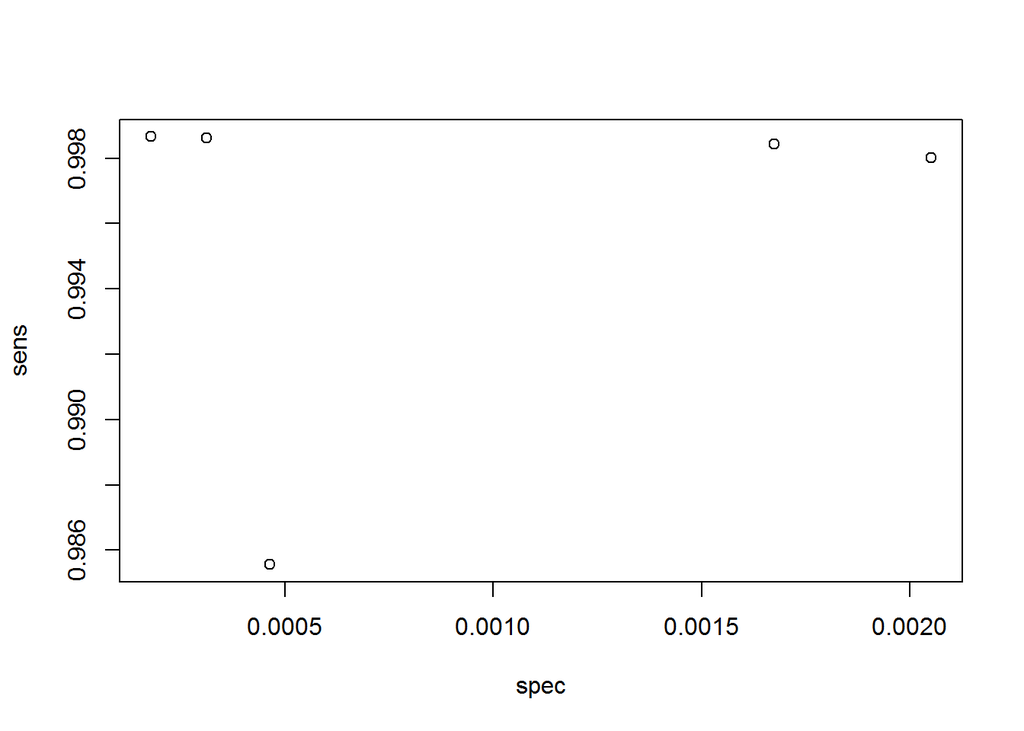

```r
sens<-cm$byClass[,1]
spec<-1-cm$byClass[,2]

plot(spec,sens)
```

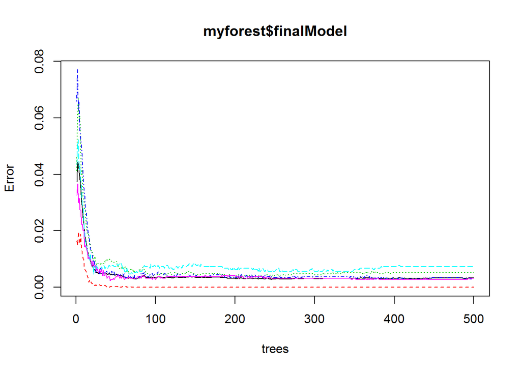

```r
plot(myforest$finalModel)
```

# Gradient Boosted Model

A gradient boosted model was fit to the data to compare with the random forest model. It has a lower accuracy and a higher misclassification rate.

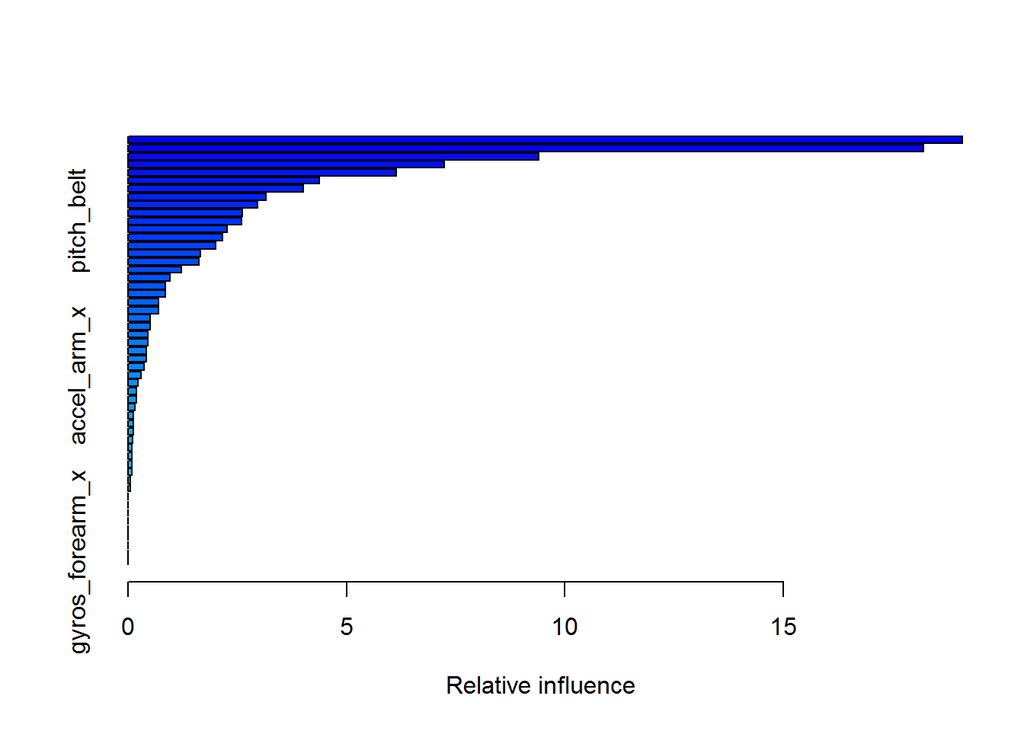

```
##                                       var     rel.inf
## roll_belt                       roll_belt 19.09602407
## num_window                     num_window 18.20066591
## pitch_forearm               pitch_forearm  9.40926550
## magnet_dumbbell_z       magnet_dumbbell_z  7.24497528
## yaw_belt                         yaw_belt  6.13782207
## magnet_dumbbell_y       magnet_dumbbell_y  4.37846285
## roll_forearm                 roll_forearm  4.01988458
## accel_dumbbell_z         accel_dumbbell_z  3.15180809
## magnet_belt_z               magnet_belt_z  2.96977629
## accel_forearm_x           accel_forearm_x  2.62201989
## pitch_belt                     pitch_belt  2.60375379
## accel_dumbbell_y         accel_dumbbell_y  2.27221478
## gyros_dumbbell_y         gyros_dumbbell_y  2.15669514
## gyros_belt_z                 gyros_belt_z  2.00035042
## roll_dumbbell               roll_dumbbell  1.65551927
## yaw_arm                           yaw_arm  1.63132510
## magnet_forearm_z         magnet_forearm_z  1.21577034
## magnet_belt_y               magnet_belt_y  0.95608769
## accel_dumbbell_x         accel_dumbbell_x  0.86321879
## accel_forearm_z           accel_forearm_z  0.85883945
## roll_arm                         roll_arm  0.70816167
## magnet_belt_x               magnet_belt_x  0.70062754
## gyros_arm_y                   gyros_arm_y  0.50651216
## total_accel_dumbbell total_accel_dumbbell  0.49928863
## magnet_arm_z                 magnet_arm_z  0.45340333
## magnet_arm_x                 magnet_arm_x  0.44854044
## gyros_belt_y                 gyros_belt_y  0.42406526
## magnet_forearm_x         magnet_forearm_x  0.41176481
## magnet_dumbbell_x       magnet_dumbbell_x  0.36294264
## accel_arm_x                   accel_arm_x  0.30458639
## gyros_dumbbell_x         gyros_dumbbell_x  0.23188610
## total_accel_forearm   total_accel_forearm  0.19841674
## accel_forearm_y           accel_forearm_y  0.18518795
## pitch_dumbbell             pitch_dumbbell  0.15074121
## magnet_arm_y                 magnet_arm_y  0.13196169
## accel_arm_y                   accel_arm_y  0.12650752
## gyros_forearm_z           gyros_forearm_z  0.11702747
## accel_arm_z                   accel_arm_z  0.11262173
## accel_belt_z                 accel_belt_z  0.09675963
## gyros_forearm_y           gyros_forearm_y  0.09393190
## gyros_dumbbell_z         gyros_dumbbell_z  0.09256978
## pitch_arm                       pitch_arm  0.08205774
## total_accel_belt         total_accel_belt  0.05887536
## magnet_forearm_y         magnet_forearm_y  0.05708301
## gyros_belt_x                 gyros_belt_x  0.00000000
## accel_belt_x                 accel_belt_x  0.00000000
## accel_belt_y                 accel_belt_y  0.00000000
## total_accel_arm           total_accel_arm  0.00000000
## gyros_arm_x                   gyros_arm_x  0.00000000
## gyros_arm_z                   gyros_arm_z  0.00000000
## yaw_dumbbell                 yaw_dumbbell  0.00000000
## yaw_forearm                   yaw_forearm  0.00000000
## gyros_forearm_x           gyros_forearm_x  0.00000000
```

```r
gbmmodel <- train(classe~., data=training, method="gbm", trControl=fitcontrol)
summary(gbmmodel)
```

```r
predictiong<-predict(gbmmodel,newdata = testing[,-54])
cm2<-confusionMatrix(testing$classe,predictiong)

cm2
```

```
## Confusion Matrix and Statistics
##
##           Reference
## Prediction    A    B    C    D    E
##          A 2229    2    0    1    0
##          B   12 1485   17    3    1
##          C    0   11 1353    3    1
##          D    1    5   18 1260    2
##          E    2    9    2   11 1418
##
## Overall Statistics
##
##                Accuracy : 0.9871
##                  95% CI : (0.9844, 0.9895)
##     No Information Rate : 0.286
##     P-Value [Acc > NIR] : < 2.2e-16
##
##                   Kappa : 0.9837
##  Mcnemar's Test P-Value : NA
##
## Statistics by Class:
##
##                      Class: A Class: B Class: C Class: D Class: E
## Sensitivity            0.9933   0.9821   0.9734   0.9859   0.9972
## Specificity            0.9995   0.9948   0.9977   0.9960   0.9963
## Pos Pred Value         0.9987   0.9783   0.9890   0.9798   0.9834
## Neg Pred Value         0.9973   0.9957   0.9943   0.9973   0.9994
## Prevalence             0.2860   0.1927   0.1772   0.1629   0.1812
## Detection Rate         0.2841   0.1893   0.1724   0.1606   0.1807
## Detection Prevalence   0.2845   0.1935   0.1744   0.1639   0.1838
## Balanced Accuracy      0.9964   0.9885   0.9855   0.9910   0.9967
```

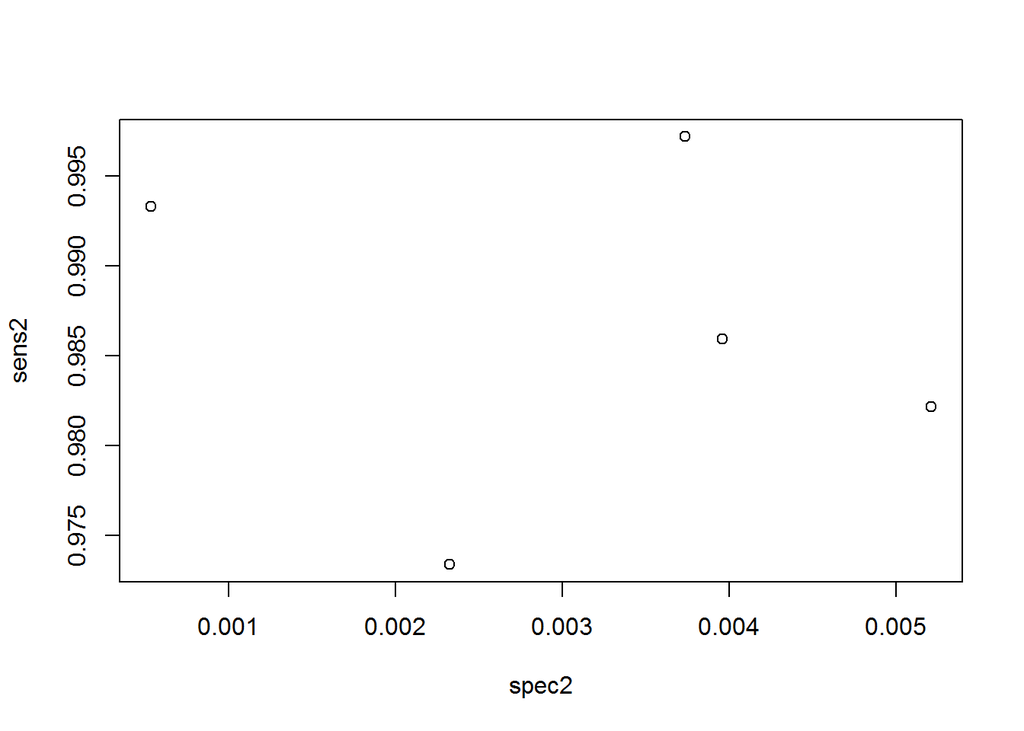

```r
sens2<-cm2$byClass[,1]
spec2<-1-cm2$byClass[,2]

plot(spec2,sens2)
```

```r
stopCluster(cluster)
registerDoSEQ()
```

# Model Selection

Comparing resampled values from both model fits, we see that the random forest algorithm out performs the gradient boosted model.

```r
library(lattice)
resampled <- resamples(list(rf=myforest,gbm=gbmmodel))
summary(resampled)
```

```
##
## Call:
## summary.resamples(object = resampled)
##
## Models: rf, gbm
## Number of resamples: 3
##
## Accuracy
##       Min. 1st Qu. Median   Mean 3rd Qu.   Max. NA's
## rf  0.9936  0.9945 0.9954 0.9952  0.9959 0.9964    0
## gbm 0.9801  0.9815 0.9829 0.9834  0.9851 0.9873    0
##
## Kappa
##       Min. 1st Qu. Median   Mean 3rd Qu.   Max. NA's
## rf  0.9919  0.9931 0.9942 0.9939  0.9948 0.9955    0
## gbm 0.9749  0.9766 0.9784 0.9791  0.9811 0.9839    0
```

# Predicting Test Cases

```r
predict(myforest,testset)
```

```
##  [1] B A B A A E D B A A B C B A E E A B B B
## Levels: A B C D E
```